# Informe P2 S2

# Análisis de accidentes vehiculares por región del Perú entre los años 2020 y 2021

# 1. Introducción

## Objetivos del proyecto

- *Visualizar* los comportamientos de las variables a través de gráficos.
- *Observar* las posibles relaciones entre las variables de la base de datos.
- *Comparar* el número de accidentes entre los períodos mencionados.
- *Analizar* los tipos de accidentes ocurridos según región.

## Planificación

A continuación se adjunta un diagrama de Gantt para mostrar la planificación y las tareas pertinentes para llevar a cabo el proyecto del curso:

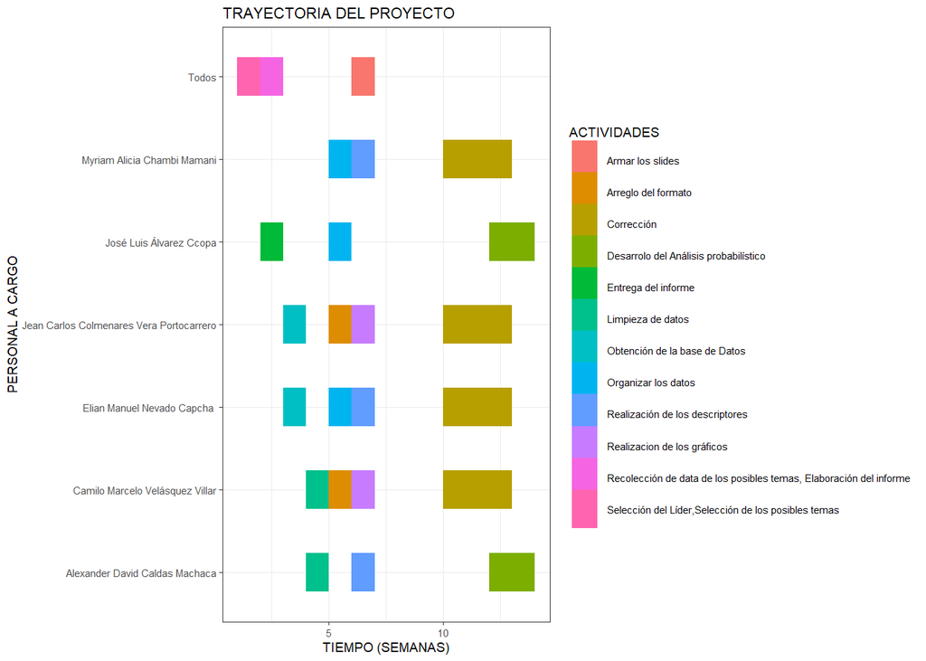

# 2. Datos

## Recolección de datos

Lo primero que hicimos fue buscar una plataforma en la cual se consigan bases de datos públicas. En este proceso uno de nuestros compañeros pudo encontrar la página web de la Plataforma Nacional de Datos Abiertos (PNDA)[^1] en la cual se logró encontrar diversas bases de datos y todas estas se encontraban categorizadas por temas, luego de ello decidimos elegir un tema específico que se considere relevante para la ejecución de nuestro proyecto. Las condiciones que se consideraron para la elección de la data fueron: publicación reciente, cantidad considerable de variables, fuente confiable, suficiente cantidad de muestras, entre otras. Finalmente, se eligió al tema de reportes preliminares de accidentes el cual logra cumplir todas las condiciones que se han mencionado anteriormente.

## Población, muestra y muestreo

El **muestreo** fue por conveniencia ya que solamente se incluyeron en la tabla de datos los accidentes que fueron reportados.

## Variables

Las variables de estudio son 11 y se adjuntan a continuación:

[output not shown]

### Limpieza de la base de datos

La limpieza de datos se hizo, por un lado, una modificación de la variable *Fecha* en Excel y en R para quitar otras variables que no son pertinentes, en las que se incluyen:

- *Fecha del reporte*
- *Número del reporte*
- *Latitud*
- *Longitud*
- *Código de la vía*
- *Kilómetro de la vía donde ocurrió*

```r
#LIBRERÍAS
library(readr)
library(dplyr)
#Limpieza de datos

Auxilio<-DF
Auxilio$X.U.FEFF.FECHA_CORTE<-NULL
Auxilio$FECHA_CORTE<-NULL
Auxilio$NRO_REPORTE<-NULL
Auxilio$LATITUD<-NULL
Auxilio$LONGITUD<-NULL
Auxilio$PROGRESIVA<-NULL
Auxilio$CODIGO_VIA<-NULL

DF<-Auxilio
DF
```

| FECHA_ACC | AÑO | MES | HORA_ACC | MODALIDAD_ACC | CANT_FALLECIDOS | CANT_HERIDOS | DEPARTAMENTO | REGIONES.NATURALES | PROVINCIA | DISTRITO |
| --- | --- | --- | --- | --- | --- | --- | --- | --- | --- | --- |
| 20200101 | 2020 | Enero | 02:30:00 | DESPISTE | 0 | 2 | AMAZONAS | SELVA | UTCUBAMBA | JAMALCA |
| 20200101 | 2020 | Enero | 06:20:00 | CHOQUE | 0 | 2 | ANCASH | COSTA | HUARAZ | HUARAZ |
| 20200101 | 2020 | Enero | 23:40:00 | CHOQUE | 0 | 0 | AREQUIPA | COSTA | CARAVELI | LOMAS |
| 20200101 | 2020 | Enero | 07:45:00 | DESPISTE | 0 | 1 | PASCO | SIERRA | PASCO | VICCO |
| 20200102 | 2020 | Enero | 00:40:00 | CHOQUE | 2 | 6 | ANCASH | COSTA | HUARMEY | HUARMEY |
| 20200102 | 2020 | Enero | 12:50:00 | DESPISTE | 2 | 16 | AREQUIPA | COSTA | ISLAY | COCACHACRA |
| 20200102 | 2020 | Enero | 16:00:00 | CHOQUE | 4 | 3 | AREQUIPA | COSTA | AREQUIPA | SAN JUAN DE TARUCANI |
| 20200102 | 2020 | Enero | 11:00:00 | ESPECIAL | 0 | 0 | AREQUIPA | COSTA | AREQUIPA | CERRO COLORADO |
| 20200102 | 2020 | Enero | 16:30:00 | CHOQUE | 0 | 3 | AREQUIPA | COSTA | AREQUIPA | UCHUMAYO |
| 20200102 | 2020 | Enero | 13:00:00 | CHOQUE | 0 | 3 | JUNIN | SIERRA | YAULI | MOROCOCHA |

[output cut: 3822 more lines]

## 3. Análisis descriptivo

### Descriptores numéricos

#### Variable Fallecidos

```r
#Hay que instalar el paquete "FinCal" con el siguiente comando: install.packages("FinCal")
library(FinCal)
```

Resumen de la variable Fallecidos

```
##    Min. 1st Qu.  Median    Mean 3rd Qu.    Max.
##  0.0000  0.0000  0.0000  0.2855  0.0000 33.0000
```

Rango, varianza y desviación estándar

```r
#Descriptores de Dispersión

range(DF$CANT_FALLECIDOS)
```

```
## [1]  0 33
```

```r
var(DF$CANT_FALLECIDOS)
```

```
## [1] 1.306623
```

```r
sd(DF$CANT_FALLECIDOS)
```

```
## [1] 1.143076
```

Coeficiente de variación

```r
coefficient.variation(sd=sd(DF$CANT_FALLECIDOS), avg = mean(DF$CANT_FALLECIDOS))
```

```
## [1] 4.003901
```

##### Análisis

El rango es de 33 y presenta una varianza de 1.306623, la desviación estándar es de 1.143076 y un coeficiente de variación de 4.003901.

## Variable Heridos

Resumen de la variable Heridos

```
##    Min. 1st Qu.  Median    Mean 3rd Qu.    Max.
##   0.000   0.000   0.000   1.435   1.000  71.000
```

Rango, varianza y desviación estándar

```
## [1]  0 71
```

```
## [1] 12.65305
```

```
## [1] 3.557112
```

Coeficiente de variación

```
## [1] 2.478788
```

##### Análisis

El mínimo número de heridos es cero, el máximo es 71, con un promedio de 1.435 y como su tercer cuartil vendría a ser 1. El rango es de 71 y presenta una varianza de 12.65305, la desviación estándar es de 3.557112 y un coeficiente de variación de 2.478788

## Variable Modalidad

Resumen tabular de la variable

```
##
## ACCIDENTE ATROPELLO    CHOQUE  DESPISTE   EMBISTE  ESPECIAL  INCENDIO VOLCADURA
##        11        94      1967      1562         9        44        65        80
```

```
##
##   ACCIDENTE   ATROPELLO      CHOQUE    DESPISTE     EMBISTE    ESPECIAL
## 0.002870564 0.024530271 0.513308977 0.407620042 0.002348643 0.011482255
##    INCENDIO   VOLCADURA
## 0.016962422 0.020876827
```

#### Análisis

Se observa que las modalidades con mayor frecuencia son las de choque y despiste.Ambos casos tienen un alto nivel de incidencias pues sobrepasan los mil casos, teniendo entre el primer tipo de accidente una diferencia de 405 casos más que el segundo tipo.

Posterior a estos tipos, los que continuarían serían los casos de atropello, volcadura, incendio y accidentes especiales. Las dos primeras con una diferencia de 14, la segunda y la tercera con una diferencia de 15, la tercera y la cuarta con una diferencia de 21 casos. Estos tipos de accidentes podemos notar que su variación es similar entre el orden en el que se presentan. Y los tipos con menores casos reportados son los de accidente y embiste; entre ellos se presenta una diferencia de 2 casos. Y podemos afirmar, según los datos, que los casos de embiste es el tipo de accidentes con menor 9 casos. Sin embargo, existe una amplia diferencia entre los casos de choque con los de embiste. En donde el primero lleva de diferencia un total de 1958 casos más que el segundo tipo.

## Variable Mes

Resumen tabular

```r
DF$MES <- factor(DF$MES, levels = c("Enero", "Febrero", "Marzo", "Abril", "Mayo",
    "Junio", "Agosto", "Setiembre", "Octubre", "Noviembre", "Diciembre"))
tabla_MES <- table(DF$MES)
tabla_MES  #Tabla de frecuencias absolutas
```

```
##
##     Enero   Febrero     Marzo     Abril      Mayo     Junio    Agosto Setiembre
##       410       367       284       231       257       260       346       349
##   Octubre Noviembre Diciembre
##       387       395       224
```

```r
prop.table(tabla_MES)  #Tabla de frecuencias relativas
```

```
##
##      Enero    Febrero      Marzo      Abril       Mayo      Junio     Agosto
## 0.11680912 0.10455840 0.08091168 0.06581197 0.07321937 0.07407407 0.09857550
##  Setiembre    Octubre  Noviembre  Diciembre
## 0.09943020 0.11025641 0.11253561 0.06381766
```

## Variable Año

Resumen tabular

```r
tabla_AÑO<-table(DF$AÑO)
tabla_AÑO #Tabla de frecuencias absolutas
```

```
## < table of extent 0 >
```

```r
prop.table(tabla_AÑO) #Tabla de frecuencias relativas
```

```
## numeric(0)
```

## Variable Departamento

Resumen tabular

```r
tabla_DEPA<-sort(table(DF$DEPARTAMENTO),decreasing=TRUE)
tabla_DEPA #Tabla de frecuencias absolutas
```

```
##
##          LIMA      AREQUIPA         JUNIN        ANCASH   LA LIBERTAD
##           872           468           317           285           227
##          PUNO           ICA         CUSCO     CAJAMARCA         PIURA
##           195           188           173           131           118
##    LAMBAYEQUE      AYACUCHO      APURIMAC       HUANUCO    SAN MARTIN
##           117            96            90            85            80
##         PASCO      MOQUEGUA       UCAYALI      AMAZONAS MADRE DE DIOS
##            73            63            59            50            39
##         TACNA        CALLAO  HUANCAVELICA        TUMBES        LORETO
##            32            30            30            10             4
```

```r
prop.table(tabla_DEPA) #Tabla de frecuencias relativas
```

```
##
##          LIMA      AREQUIPA         JUNIN        ANCASH   LA LIBERTAD
##   0.227557411   0.122129436   0.082724426   0.074373695   0.059237996
##          PUNO           ICA         CUSCO     CAJAMARCA         PIURA
##   0.050887265   0.049060543   0.045146138   0.034185804   0.030793319
##    LAMBAYEQUE      AYACUCHO      APURIMAC       HUANUCO    SAN MARTIN
##   0.030532359   0.025052192   0.023486430   0.022181628   0.020876827
##         PASCO      MOQUEGUA       UCAYALI      AMAZONAS MADRE DE DIOS
##   0.019050104   0.016440501   0.015396660   0.013048017   0.010177453
##         TACNA        CALLAO  HUANCAVELICA        TUMBES        LORETO
##   0.008350731   0.007828810   0.007828810   0.002609603   0.001043841
```

#### Análisis

En cuanto a la variable departamento podemos percibir que como era de esperarse Lima es el departamento con mayor cantidad de accidentes de tránsito con 872 accidentes ocurridos. Esta cifra tiene una explicación bastante concreta pues Lima es el departamento que abarca la mayor cantidad de habitantes por sobre todos los demás departamentos. Asimismo, por ser Lima la capital del país es un punto en donde existe un exceso de vehículos y por ello puede considerarse como una predisposición ante los accidentes que por lo general ocurren en la capital.

El segundo departamento que contiene una de las mayores cantidades de accidentes es Arequipa con 468 accidentes ocurridos y precisamente es también el quinto departamento con mayor población, pero también podemos destacar es que el departamento al cual tienen mayor accesibilidad los demás departamentos del sur del país y esta carretera es por la cual se viaja a departamentos del sur del país. Esta es una de las posibles causas por las cuales esta región es acreedora del segundo lugar con la mayor cantidad de accidentes de tránsito. Sin embargo, pese a ser la segunda región con mayor cantidad de accidentes ocurridos en el Perú. Arequipa se diferencia de Lima por 404 casos de accidentes de tránsito ocurridos.

El tercer departamento con mayor cantidad de accidentes de tránsito es el distrito de Junín, con 317 accidentes ocurridos en esta región. Asimismo, este departamento ocupa el séptimo lugar con mayor cantidad de habitantes, esta podría ser una de las causas por las cuales existen esta cantidad de accidentes en su región.

El cuarto departamento con gran cantidad de accidentes es la región de accidentes es el departamento de Áncash con 285 accidentes ocurridos en este territorio, una de las probabilidades por las cuales este departamento este entre los cinco primeros departamentos con mayor cantidad de accidentes es que se encuentra al norte del país, por ello el camino para ir tanto al centro como al norte del país. Asimismo, la Panamericana Norte es una de las carreteras con mayor circulación de vehículos después de la Panamericana Sur, pero también en esta carretera es donde comúnmente se presentan la mayor cantidad de accidentes.

Uno de los datos que más relevantes por mencionar es que Loreto es el departamento con menor cantidad de accidentes de tránsito en el país, con 4 accidentes en esta región. La diferencia entre la cantidad de accidentes ocurridos en la capital del país es demasiado extensa, pues es mayor que la región Loreto por 868 accidentes de más.

## Descriptores gráficos

### Boxplot de fallecidos:

Esta gráfica nos muestra la cantidad de fallecidos que hay por accidente de tránsito.

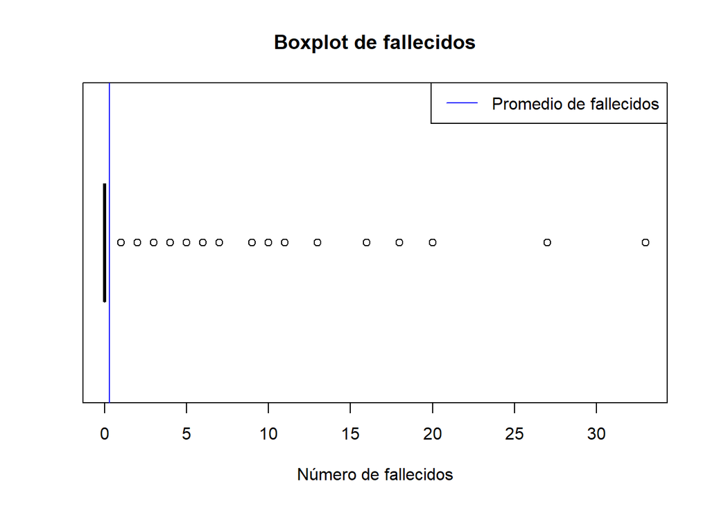

### Boxplot de heridos

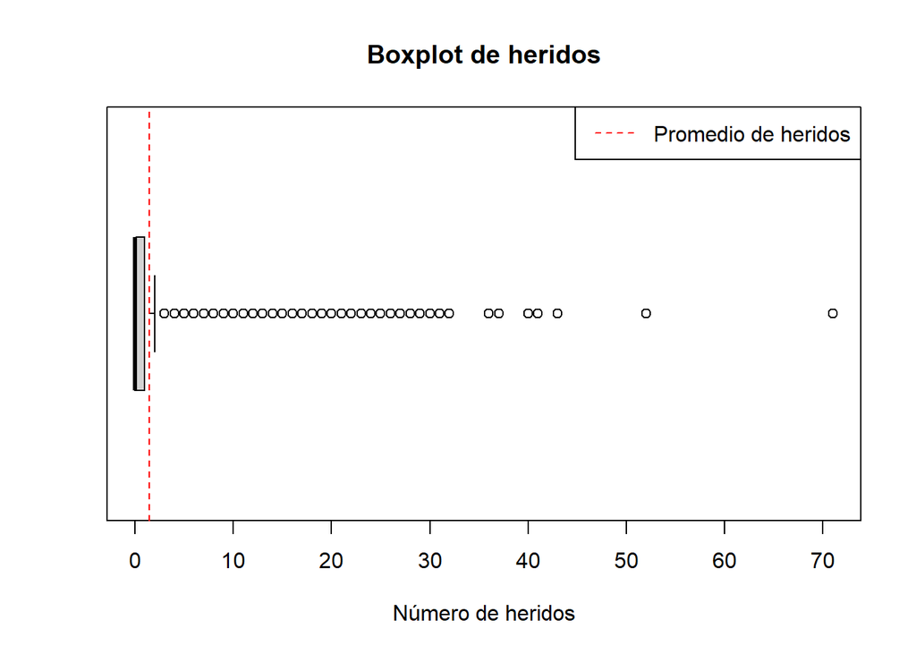

```r
boxplot(DF$CANT_HERIDOS,horizontal=TRUE, main="Boxplot de heridos", xlab = "Número de heridos")
abline(v=mean(DF$CANT_HERIDOS),col="red",lty=2)
legend("topright",legend = "Promedio de heridos",col="red",lty=2)
```

### Relación entre fallecidos y heridos

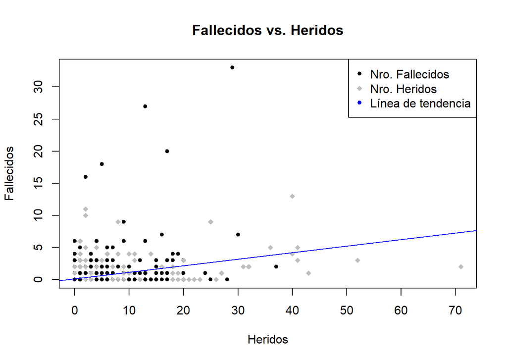

```r
plot(DF$CANT_FALLECIDOS~DF$CANT_HERIDOS,pch=c(20,18),col=c("black","gray"),main="Fallecidos vs. Heridos",xlab="Heridos",ylab="Fallecidos")
abline(lm(DF$CANT_FALLECIDOS~DF$CANT_HERIDOS),col="blue",lty=1)
legend("topright",legend=c("Nro. Fallecidos","Nro. Heridos","Línea de tendencia"),col=c("black","gray","blue"),pch=c(20,18))
```

Se observa que hay una leve correlación entre las dos variables con un valor de 0.3158551. Ambas variables se concentran al inicio pero divergen conforme la cantidad aumenta.

### Fallecidos y heridos según región:

```r
#Subsetting para los fallecidos por región
Accidentes_costa<-subset(DF,REGIONES.NATURALES=="COSTA")
Accidentes_selva<-subset(DF,REGIONES.NATURALES=="SELVA")
Accidentes_sierra<-subset(DF,REGIONES.NATURALES=="SIERRA")

#Organización de los meses en orden cronológico
DF$MES<-factor(DF$MES, levels = c("Enero", "Febrero", "Marzo", "Abril", "Mayo", "Junio", "Agosto", "Setiembre", "Octubre", "Noviembre", "Diciembre"))

#Tabla de proporción entre fallecidos por región
round(table(DF$REGIONES.NATURALES)/nrow(DF),digits=2)
```

```
##
##  COSTA  SELVA SIERRA
##   0.63   0.06   0.31
```

## Boxplot de fallecidos

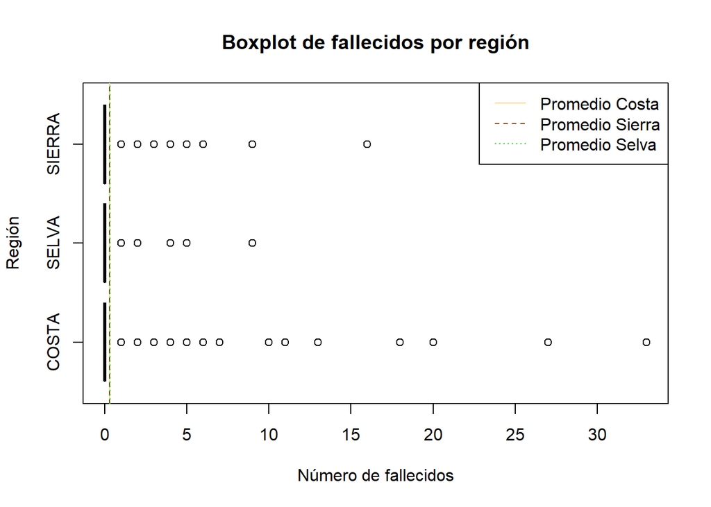

```r
#Boxplot
boxplot(DF$CANT_FALLECIDOS~DF$REGIONES.NATURALES,
        horizontal = TRUE,
        main="Boxplot de fallecidos por región",
        xlab="Número de fallecidos",
        ylab="Región",
        col=c("burlywood1","saddlebrown","limegreen"))
abline(v=mean(Accidentes_costa$CANT_FALLECIDOS),lty=1,col="burlywood1")
abline(v=mean(Accidentes_sierra$CANT_FALLECIDOS),lty=2,col="saddlebrown")
abline(v=mean(Accidentes_selva$CANT_FALLECIDOS),lty=3,col="limegreen")
legend("topright",legend=c("Promedio Costa","Promedio Sierra","Promedio Selva"),col=c("burlywood1","saddlebrown","limegreen"),lty=c(1,2,3))
```

Esta gráfica nos muestra el boxplot del número de fallecidos en cada región natural, donde analizaremos las medianas y datos atípicos por región natural.

### Boxplot de heridos según región

[output not shown]

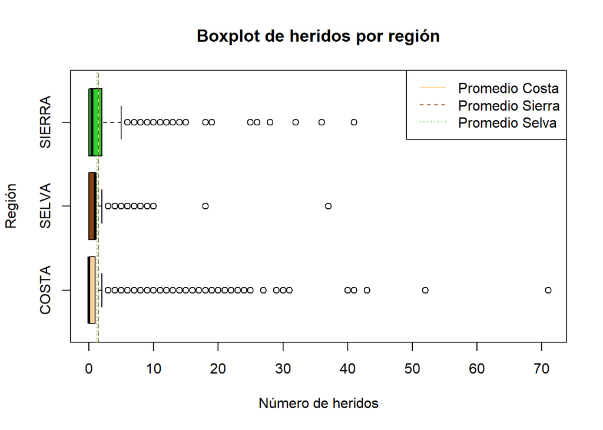

Esta gráfica nos muestra el boxplot del número de heridos en cada región natural, donde analizaremos las medianas y datos atípicos por región natural.

### Accidentes en la costa por mes

```
##
##     Enero   Febrero     Marzo     Abril      Mayo     Junio    Agosto Setiembre
##       255       241       170       153       160       162       220       222
##   Octubre Noviembre Diciembre
##       226       245       139
```

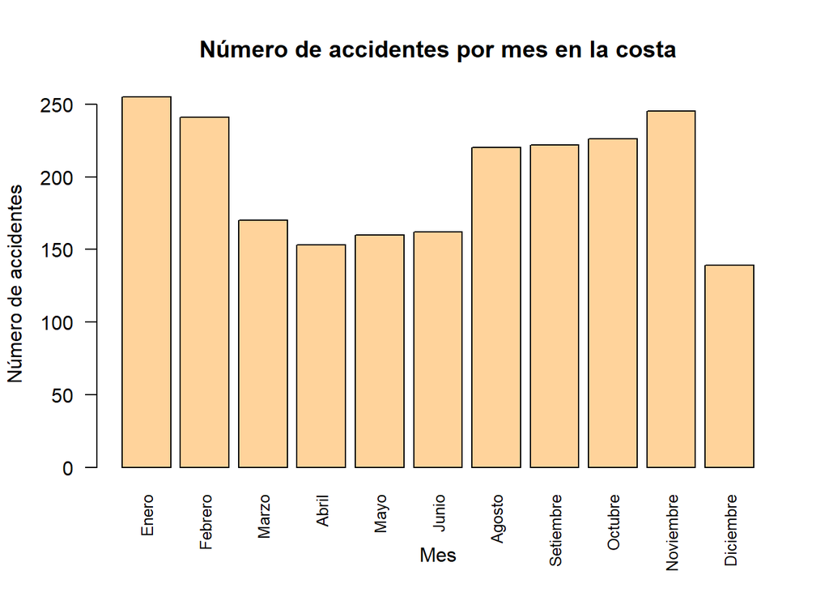

### Accidentes en la sierra por mes

```
##
##     Enero   Febrero     Marzo     Abril      Mayo     Junio    Agosto Setiembre
##       132       111       102        72        81        82        93       101
##   Octubre Noviembre Diciembre
##       133       122        74
```

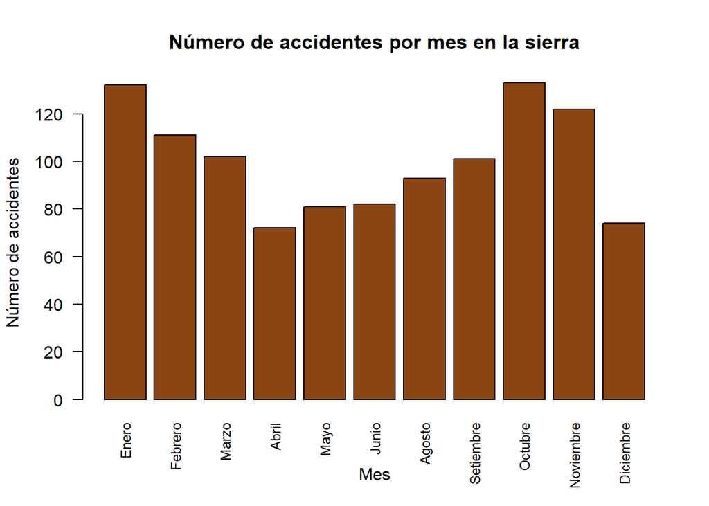

### Accidentes en la selva por mes

```
##
##     Enero   Febrero     Marzo     Abril      Mayo     Junio    Agosto Setiembre
##        23        15        12         6        16        16        33        26
##   Octubre Noviembre Diciembre
##        28        28        11
```

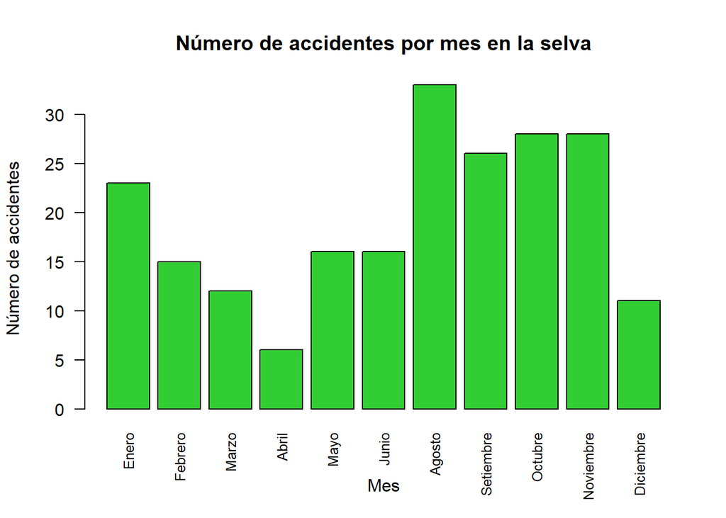

### Accidentes por departamento

```
##
##      AMAZONAS        ANCASH      APURIMAC      AREQUIPA      AYACUCHO
##            50           285            90           468            96
##     CAJAMARCA        CALLAO         CUSCO  HUANCAVELICA       HUANUCO
##           131            30           173            30            85
##           ICA         JUNIN   LA LIBERTAD    LAMBAYEQUE          LIMA
##           188           317           227           117           872
##        LORETO MADRE DE DIOS      MOQUEGUA         PASCO         PIURA
##             4            39            63            73           118
##          PUNO    SAN MARTIN         TACNA        TUMBES       UCAYALI
##           195            80            32            10            59
```

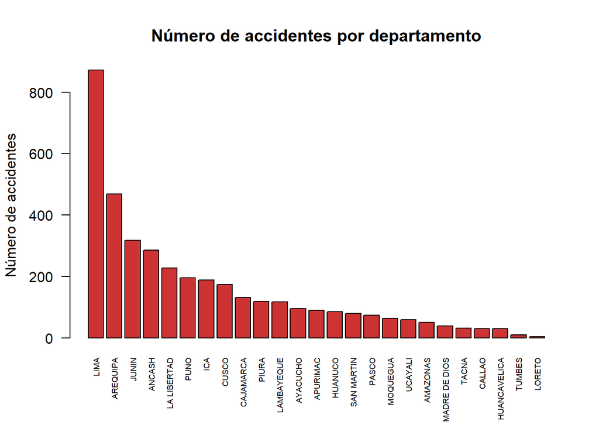

#### Accidentes por departamento en la costa

```
##
##      ANCASH    AREQUIPA      CALLAO         ICA LA LIBERTAD  LAMBAYEQUE
##         285         468          30         188         227         117
##        LIMA    MOQUEGUA       PIURA       TACNA      TUMBES
##         872          63         118          32          10
```

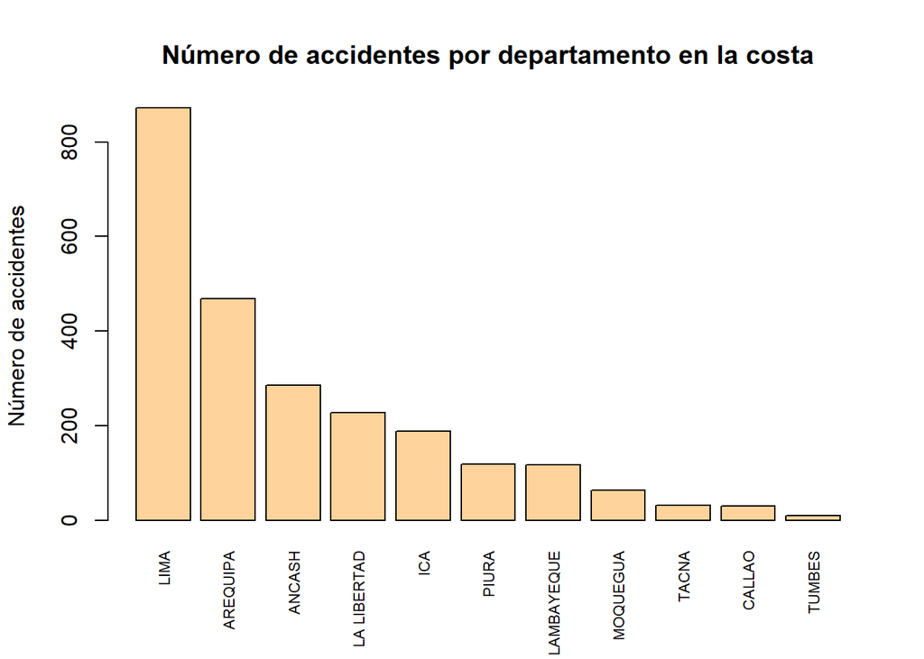

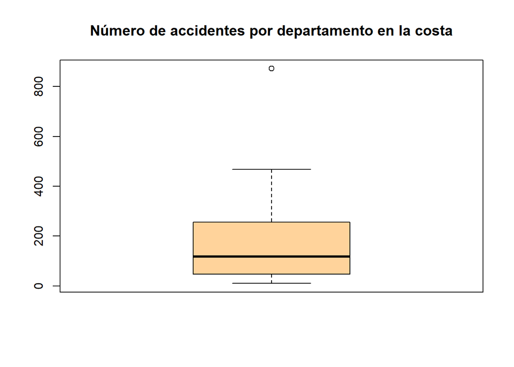

### Accidentes por departamento en la sierra

```r
table(Accidentes_sierra$DEPARTAMENTO)
```

```
##
##     APURIMAC     AYACUCHO    CAJAMARCA        CUSCO HUANCAVELICA      HUANUCO
##           90           96          131          173           30           85
##        JUNIN        PASCO         PUNO
##          317           73          195
```

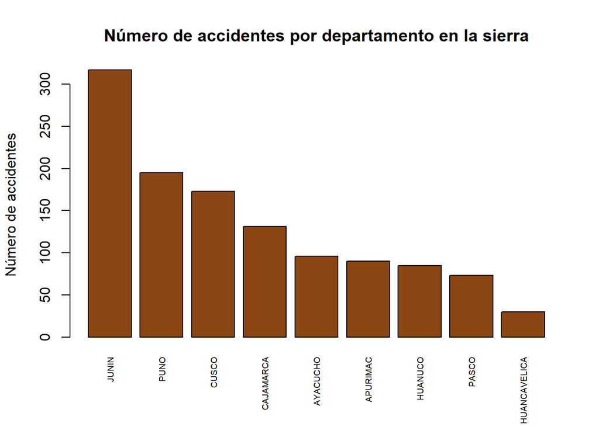

```r
barplot(sort(table(Accidentes_sierra$DEPARTAMENTO),decreasing=TRUE), ylab = "Número de accidentes", main = "Número de accidentes por departamento en la sierra", col = "saddlebrown",cex.names=0.6, las=3)
```

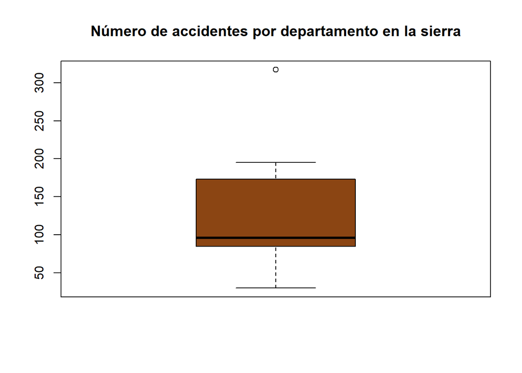

```r
boxplot(table(Accidentes_sierra$DEPARTAMENTO),main = "Número de accidentes por departamento en la sierra",col="saddlebrown")
```

### Accidentes por departamento en la selva

```r
table(Accidentes_selva$DEPARTAMENTO)
```

```
##
##      AMAZONAS        LORETO MADRE DE DIOS    SAN MARTIN       UCAYALI
##            50             4            39            80            59
```

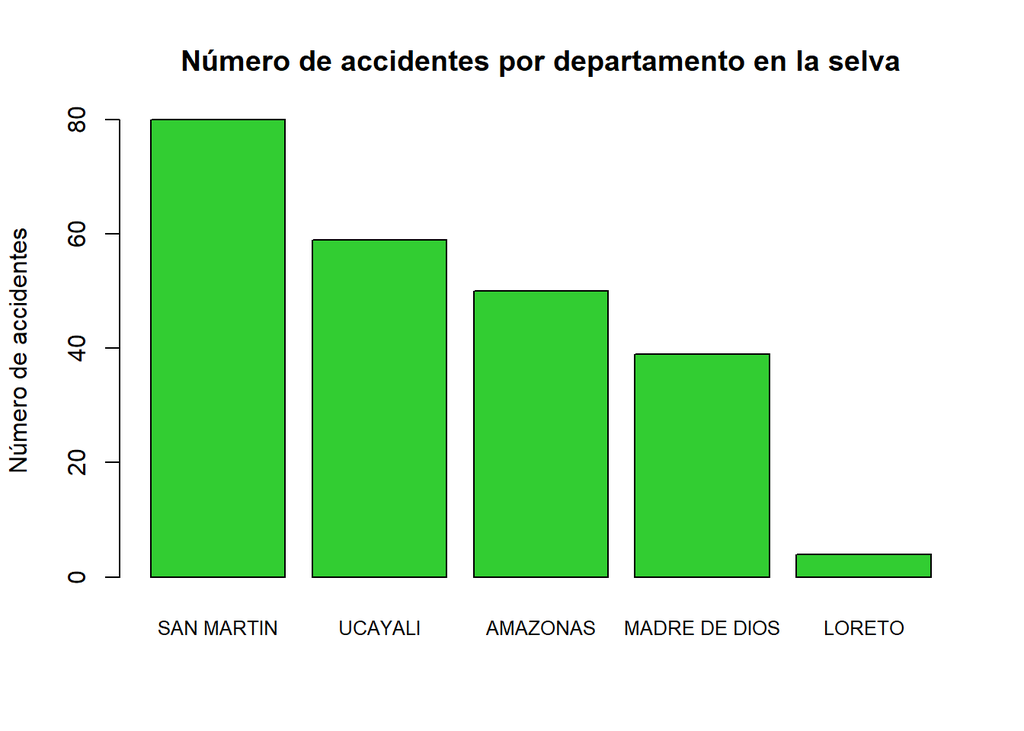

```r
barplot(sort(table(Accidentes_selva$DEPARTAMENTO),decreasing=TRUE), ylab = "Número de accidentes", main = "Número de accidentes por departamento en la selva", col = "limegreen",cex.names=0.8)
```

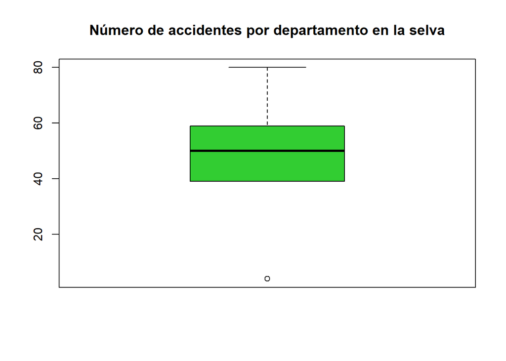

```r
boxplot(table(Accidentes_selva$DEPARTAMENTO),main = "Número de accidentes por departamento en la selva",col="limegreen")
```

### Cantidad de fallecidos por accidente en la costa

```r
table(Accidentes_costa$CANT_FALLECIDOS)
```

```
##
##    0    1    2    3    4    5    6    7   10   11   13   18   20   27   33
## 2010  305   48   23    8    4    3    2    1    1    1    1    1    1    1
```

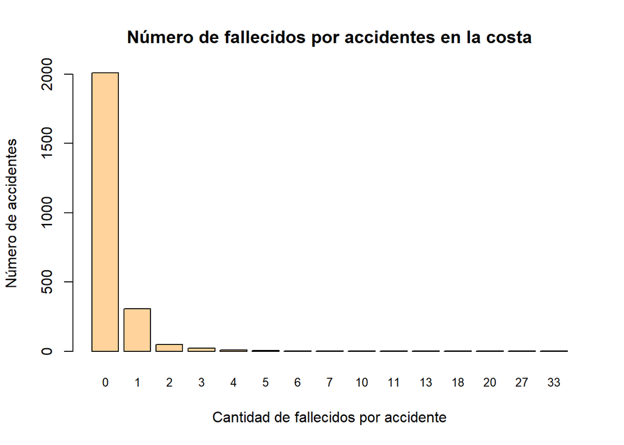

```r
barplot(sort(table(Accidentes_costa$CANT_FALLECIDOS), decreasing = TRUE), xlab = "Cantidad de fallecidos por accidente", ylab = "Número de accidentes", main = "Número de fallecidos por accidentes en la costa", col = "burlywood1", cex.names = 0.8)
```

### Cantidad de fallecidos por accidente en la sierra

```r
table(Accidentes_sierra$CANT_FALLECIDOS)
```

```
##
##   0   1   2   3   4   5   6   9  16
## 980 158  25  14   4   3   3   2   1
```

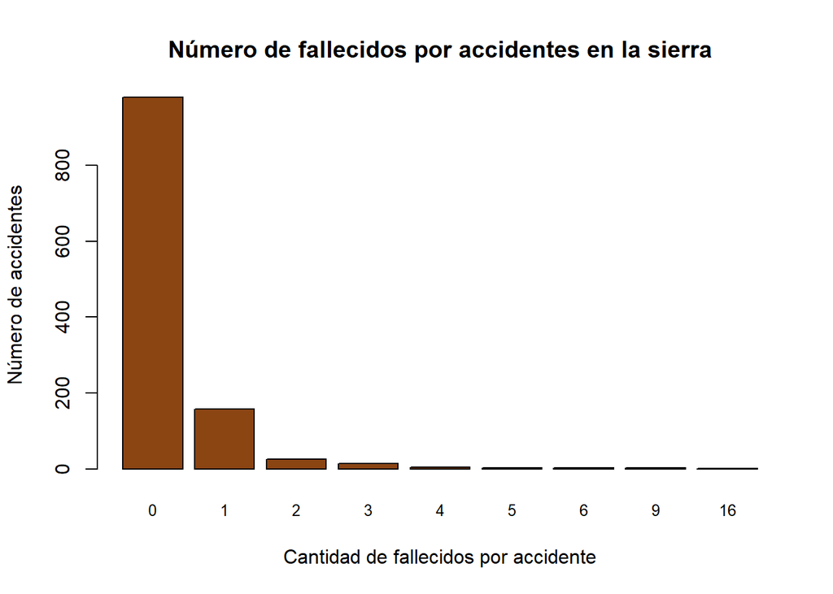

```r
barplot(sort(table(Accidentes_sierra$CANT_FALLECIDOS), decreasing = TRUE), xlab = "Cantidad de fallecidos por accidente", ylab = "Número de accidentes", main = "Número de fallecidos por accidentes en la sierra", col = "saddlebrown", cex.names = 0.8)
```

### Cantidad de fallecidos por accidente en la selva

```r
table(Accidentes_selva$CANT_FALLECIDOS)
```

```
##
##   0   1   2   4   5   9
## 182  37  10   1   1   1
```

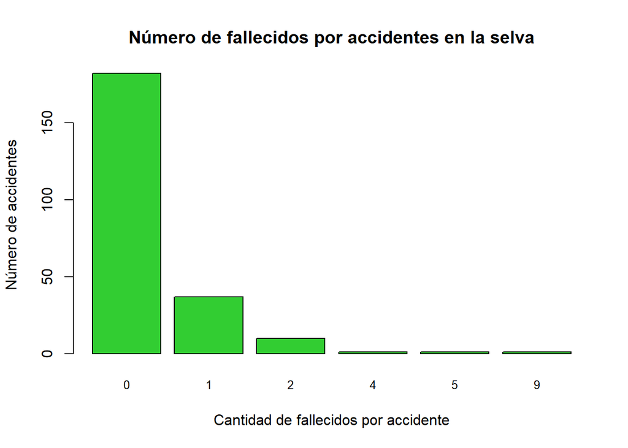

```r
barplot(sort(table(Accidentes_selva$CANT_FALLECIDOS), decreasing = TRUE), xlab = "Cantidad de fallecidos por accidente", ylab = "Número de accidentes", main = "Número de fallecidos por accidentes en la selva", col = "limegreen", cex.names = 0.8)
```

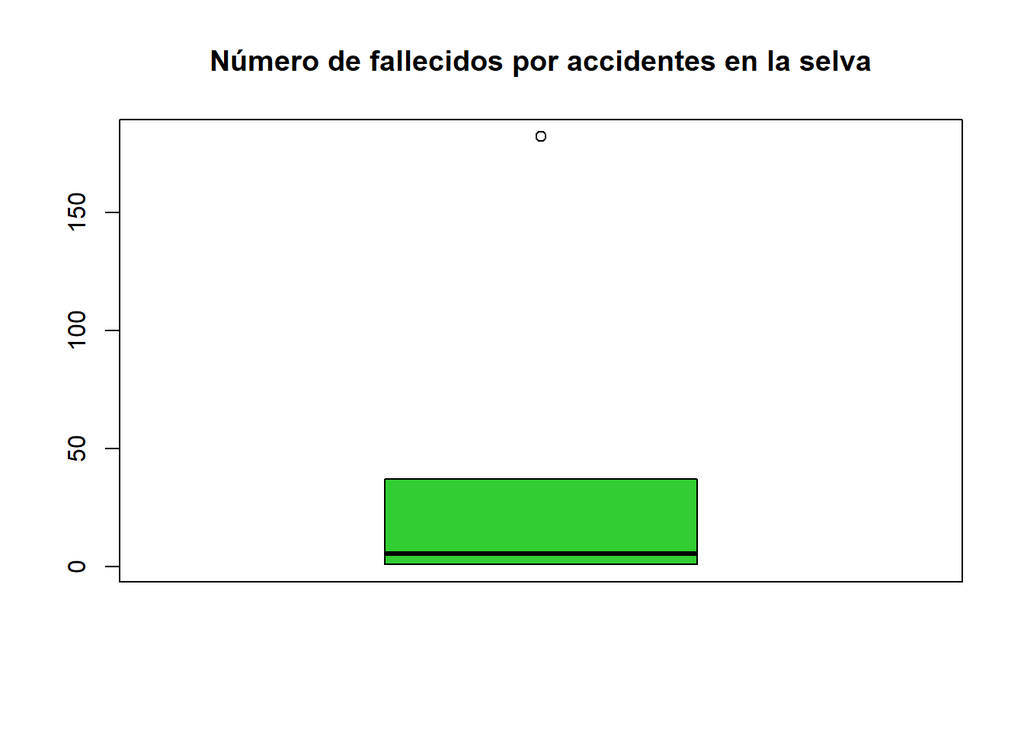

```r
boxplot(table(Accidentes_selva$CANT_FALLECIDOS),main = "Número de fallecidos por accidentes en la selva", col = "limegreen") ##aun no funciona
```

```r
table(Accidentes_costa$CANT_FALLECIDOS!=0)
```

```
##
## FALSE  TRUE
##  2010   400
```

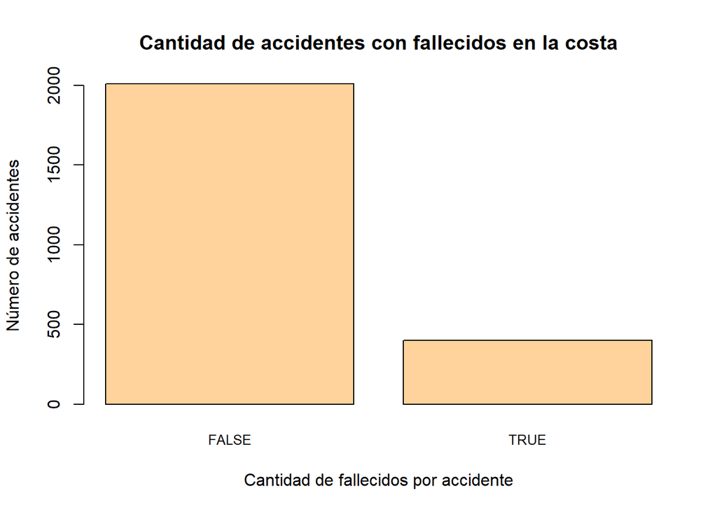

```r
barplot(sort(table(Accidentes_costa$CANT_FALLECIDOS!=0), decreasing = TRUE), xlab = "Cantidad de fallecidos por accidente", ylab = "Número de accidentes", main = "Cantidad de accidentes con fallecidos en la costa", col = "burlywood1", cex.names = 0.8)
```

```r
table(Accidentes_sierra$CANT_FALLECIDOS!=0)
```

```
##
## FALSE  TRUE
##   980   210
```

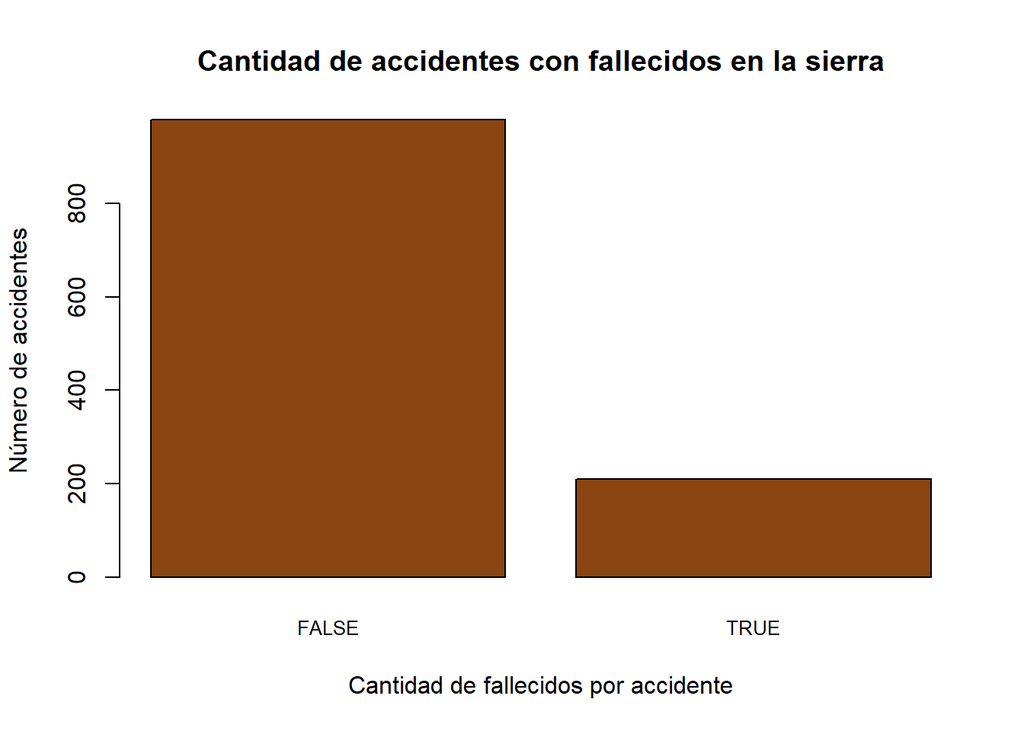

```r
barplot(sort(table(Accidentes_sierra$CANT_FALLECIDOS!=0), decreasing = TRUE), xlab = "Cantidad de fallecidos por accidente", ylab = "Número de accidentes", main = "Cantidad de accidentes con fallecidos en la sierra", col = "saddlebrown", cex.names = 0.8)
```

```r
table(Accidentes_selva$CANT_FALLECIDOS!=0)
```

```
##
## FALSE  TRUE
##   182    50
```

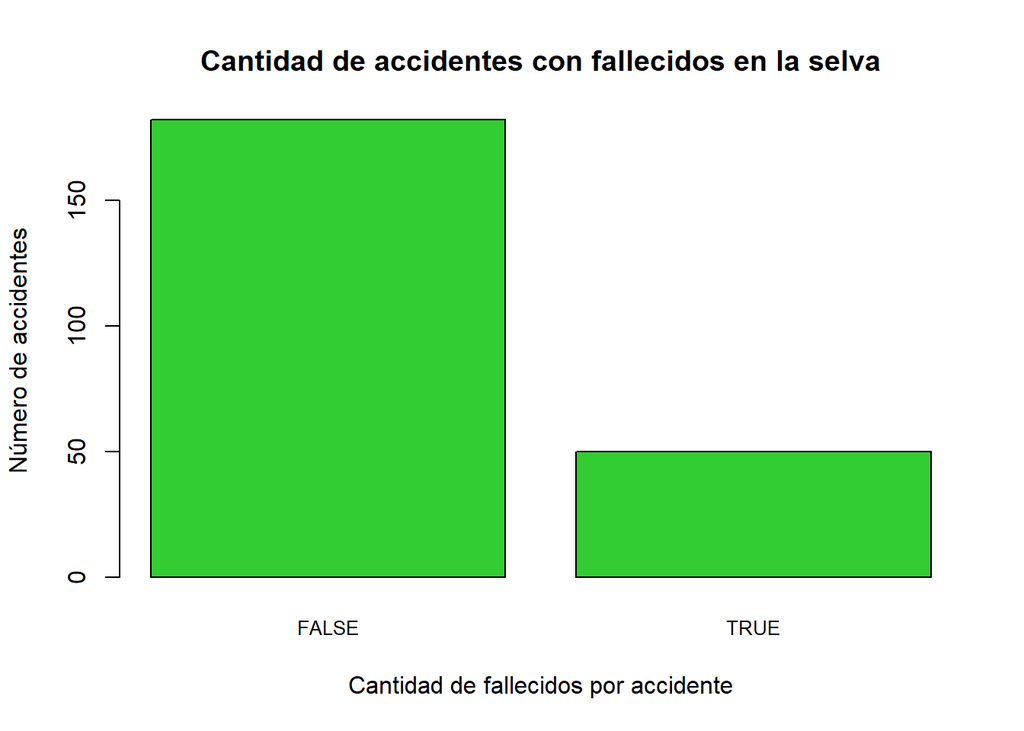

```r
barplot(sort(table(Accidentes_selva$CANT_FALLECIDOS!=0), decreasing = TRUE), xlab = "Cantidad de fallecidos por accidente", ylab = "Número de accidentes", main = "Cantidad de accidentes con fallecidos en la selva", col = "limegreen", cex.names = 0.8)
```

### Mapa de calor de accidentes según provincia

[output not shown]

[output not shown]

```
##  [1] "OBJECTID_1" "OBJECTID"   "CCDD"       "NOMBDEP"    "CCPP"
##  [6] "NOMBPROV"   "CAPITAL"    "IDPROV"     "Shape_STAr" "Shape_STLe"
## [11] "ORIG_FID"   "Shape_Leng" "Shape_Area" "CONTACTO"   "CORREO"
## [16] "WHATSAPP"
```

```
##  [1] "ï..FECHA_CORTE"     "NRO_REPORTE"        "FECHA_ACC"
##  [4] "AÃ.O"               "MES"                "HORA_ACC"
##  [7] "MODALIDAD_ACC"      "CANT_FALLECIDOS"    "CANT_HERIDOS"
## [10] "LATITUD"            "LONGITUD"           "PROGRESIVA"
## [13] "CODIGO_VIA"         "DEPARTAMENTO"       "REGIONES.NATURALES"
## [16] "PROVINCIA"          "DISTRITO"
```

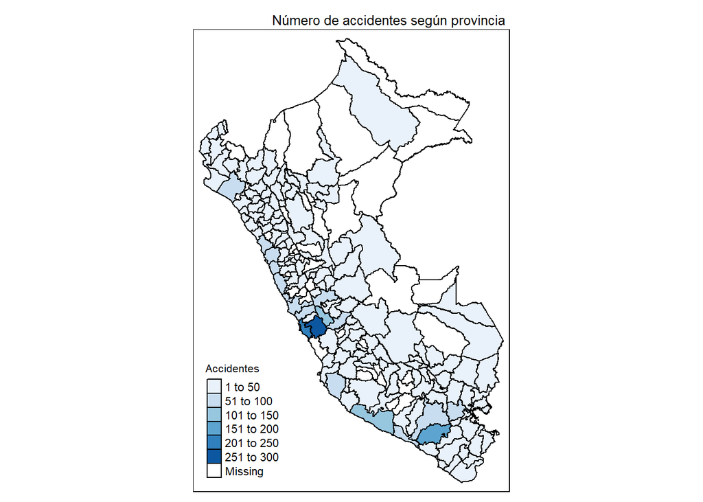

### Mapa de calor de fallecidos según provincia

```
##  [1] "OBJECTID_1" "OBJECTID"   "CCDD"       "NOMBDEP"    "CCPP"
##  [6] "NOMBPROV"   "CAPITAL"    "IDPROV"     "Shape_STAr" "Shape_STLe"
## [11] "ORIG_FID"   "Shape_Leng" "Shape_Area" "CONTACTO"   "CORREO"
## [16] "WHATSAPP"
```

```
##  [1] "ï..FECHA_CORTE"     "NRO_REPORTE"        "FECHA_ACC"
##  [4] "AÃ.O"               "MES"                "HORA_ACC"
##  [7] "MODALIDAD_ACC"      "CANT_FALLECIDOS"    "CANT_HERIDOS"
## [10] "LATITUD"            "LONGITUD"           "PROGRESIVA"
## [13] "CODIGO_VIA"         "DEPARTAMENTO"       "REGIONES.NATURALES"
## [16] "PROVINCIA"          "DISTRITO"
```

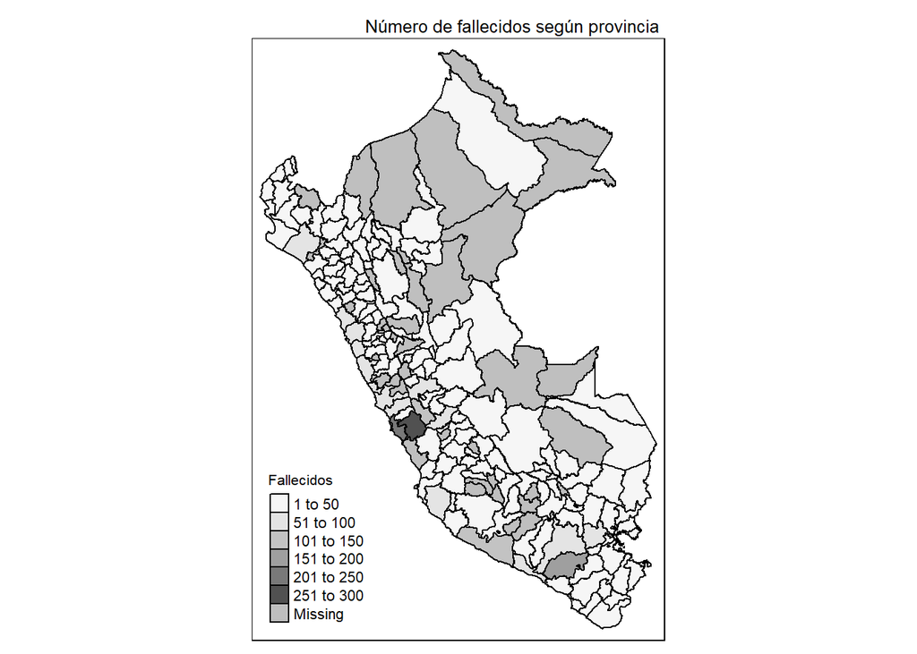

## 4. Análisis probabilístico

### Variables aleatorias

#### Variable heridos

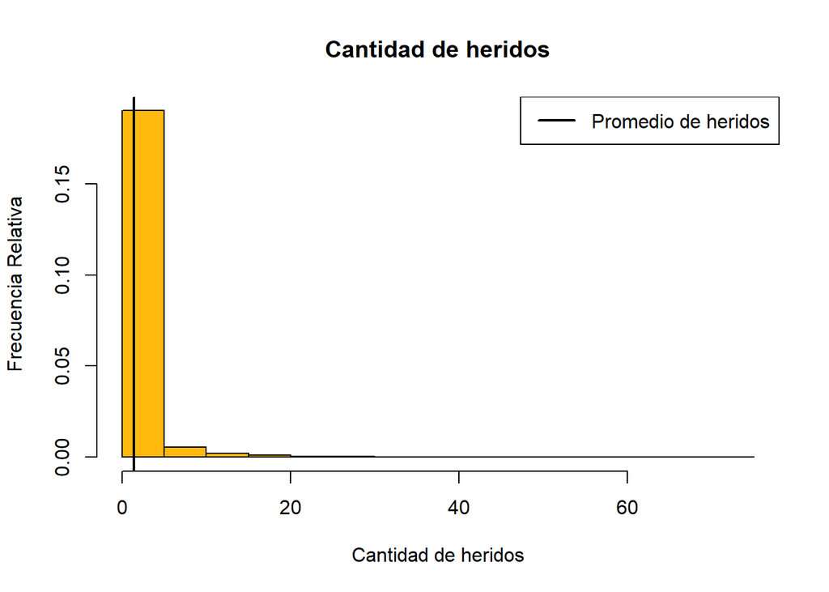

```r
hist(DF$CANT_HERIDOS, xlab="Cantidad de heridos", ylab="Frecuencia Relativa", probability = TRUE, main="Cantidad de heridos", col="darkgoldenrod1")
abline(v=c(mean(DF$CANT_HERIDOS, na.rm=TRUE)), col=c("black"), lwd=c(2))
legend("topright", legend=c("Promedio de heridos"), col=c("black"), lwd=2)
```

Como podemos ver en el gráfico respecto al análisis descriptivo de esta sección. La variable `CANT_HERIDOS` parece distribuirse como una variable aleatoria exponencial decreciente.

Veamos si lo planteado se puede sostener:

Primero, planteemos cómo sería nuestra distribución exponencial decreciente. denominamos $Z$ a nuestra variable aleatoria.

lo planteado es que:
$$Z\sim
Exp(\lambda)$$

```r
Z <- DF$CANT_HERIDOS[!is.na(DF$CANT_HERIDOS)]
```

El parámetro de esta distribución se puede determinar por el inverso de la media $\lambda$.

```r
Lambda1 <- (1/mean(Z))
Lambda1
```

```
## [1] 0.696854
```

Después de presentar todo lo anterior graficamos la densidad de la variable aleatoria continua $Z$ sobre el histograma de nuestras frecuencias relativas. Tomaremos el parámetro `breaks=10` para hacer la comparación aproximada, puesto que según la data provista la cantidad de heridos es una variable discreta.

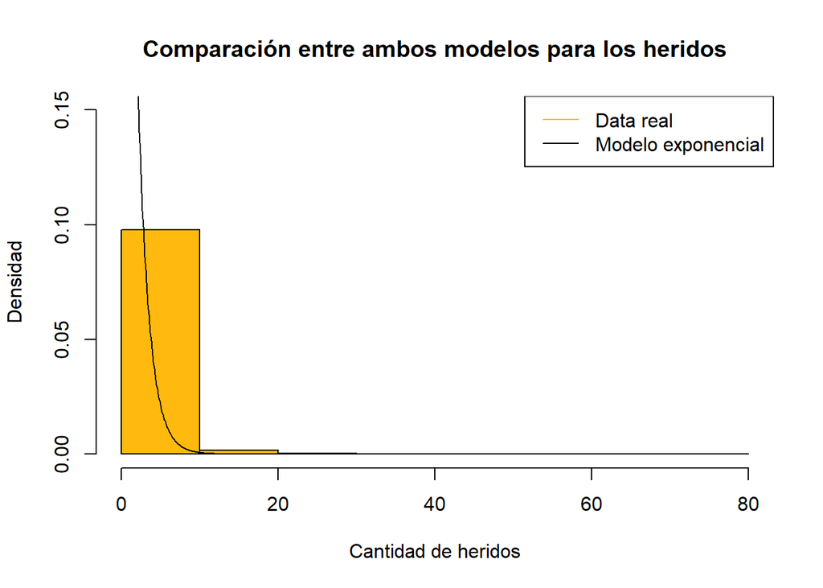

```r
a <- seq(0, max(Z, na.rm=TRUE), 0.1)
b <- dexp(a, rate=Lambda1)
hist(Z, probability=TRUE, ylim=c(0,0.15), col="darkgoldenrod1", main=paste("Comparación entre ambos modelos para los heridos"), xlab="Cantidad de heridos",ylab="Densidad", breaks=10)
lines(a,b, col="black", lwd=1)
legend("topright", legend=c("Data real","Modelo exponencial"), col=c("darkgoldenrod1","black"), lwd=1)
```

Observamos que existe un parecido entre forma entre la densidad de la variable aleatoria continua y el histograma.

Para seguir demostrando la semejanza comparamos algunos descriptores numéricos: Comenzamos con la media para hallar el parámetro,

Partimos de la media para hallar el parámetro $\lambda$, por lo mencionado sabemos que la media de la variable en la práctica será igual al valor esperado de la variable teórica.

la varianza tendría que ser cercana a $\mathsf{Var}(Z)=\frac{1}{\lambda^2}$.

```r
1/Lambda1^2
```

```
## [1] 2.059285
```

```r
var(Z)
```

```
## [1] 12.65305
```

De igual forma, la desviación estándar teórica debería tener un valor aproximado a la desviación estándar en la práctica.

$\mathsf{Sd}(Z)=\frac{1}{\lambda}$.

```r
1/Lambda1
```

```
## [1] 1.435021
```

```r
sd(Z)
```

```
## [1] 3.557112
```

```r
coefficient.variation(sd=sd(Z), avg = mean(Z))
```

```
## [1] 2.478788
```

#### Variable fallecidos

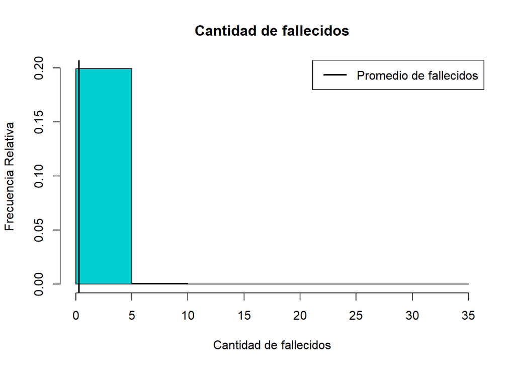

```r
FALLECIDOSCOMPLETOS<-DF$CANT_FALLECIDOS[!is.na(DF$CANT_FALLECIDOS)]
hist(FALLECIDOSCOMPLETOS, xlab="Cantidad de fallecidos", ylab="Frecuencia Relativa", probability = TRUE, main="Cantidad de fallecidos", col="darkturquoise",breaks=10)
abline(v=c(mean(DF$CANT_FALLECIDOS, na.rm=TRUE)), col=c("black"), lwd=c(2))
legend("topright", legend=c("Promedio de fallecidos"), col=c("black"), lwd=2)
```

Veamos si nuestra hipótesis se puede sustentar.

Primero, planteemos cómo sería esta distribución exponencial. Llamemos $T$ a nuestra variable aleatoria.

Lo planteado es que:
$$T \sim
Exp(\lambda)$$

```r
T <- DF$CANT_FALLECIDOS[!is.na(DF$CANT_FALLECIDOS)]
```

El parámetro de esta distribución se puede determinar a través del inverso multiplicativo de su media $\lambda$.

```r
Lambda2 <- (1/mean(T))
Lambda2
```

```
## [1] 3.502742
```

Después de presentar todo lo anterior graficamos la densidad de la variable aleatoria continua $T$ sobre el histograma de nuestras frecuencias relativas. Tomaremos el parámetro `breaks=10` para hacer la comparación aproximada, puesto que según la data provista la cantidad de fallecidos es una variable discreta.

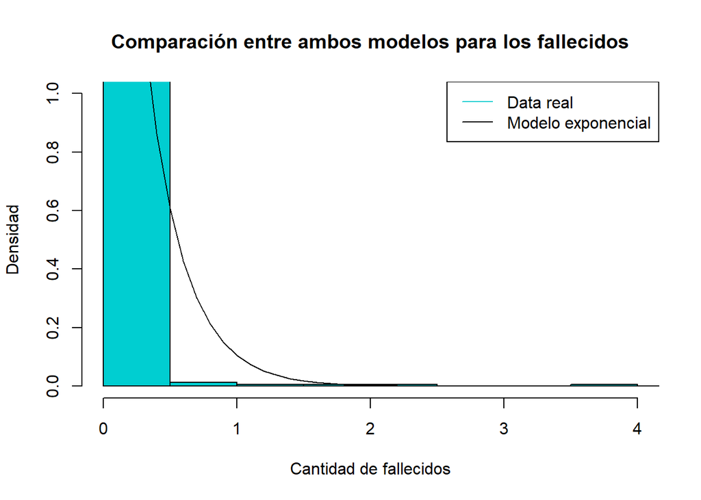

```r
d <- seq(0, max(T, na.rm=TRUE), 0.1)
e <- dexp(d, rate=Lambda2)
hist(e, probability=TRUE, ylim=c(0, 1), col="darkturquoise", main="Comparación entre ambos modelos para los fallecidos", ylab="Densidad",xlab="Cantidad de fallecidos", breaks=10)
lines(d,e, col="black", lwd=1)
legend("topright", legend=c("Data real","Modelo exponencial"), col=c("darkturquoise","black"), lwd=1)
```

Para seguir demostrando la semejanza comparamos algunos descriptores numéricos: Comenzamos con la media para hallar el parámetro,

Partimos de la media para hallar el parámetro $\lambda$, por lo mencionado sabemos que la media de la variable en la práctica será igual al valor esperado de la variable teórica.

la varianza tendría que ser cercana a $\mathsf{Var}(T)=\frac{1}{\lambda^2}$.

```r
1/Lambda2^2
```

```
## [1] 0.08150489
```

```r
var(T)
```

```
## [1] 1.306623
```

De igual forma, la desviación estándar teórica debería tener un valor aproximado a la desviación estándar en la práctica.

$\mathsf{Sd}(T)=\frac{1}{\lambda}$.

```r
1/Lambda2
```

```
## [1] 0.2854906
```

```r
sd(T)
```

```
## [1] 1.143076
```

```r
coefficient.variation(sd=sd(T), avg = mean(T))
```

```
## [1] 4.003901
```

[^1]: Plataforma Nacional de Datos Abiertos (2021). [Enlace](https://www.datosabiertos.gob.pe/dataset/reportes-preliminares-de-accidentes-centro-de-gesti%C3%B3n-y-monitoreo)